# Analysis_notebook

Loading libraries

```r
library(tidyverse)
```

```r
library(dplyr)
library(ggplot2)
library(tidyr)
library(stringr)
library(janitor)
```

Loading and Viewing the first 6 rows of the table

```r
activity_sleep_weight <- read_csv("./Data/cleaned_data/activity_sleep_weight_daily_joined_08_05_2022_v02.csv")
head(activity_sleep_weight)
```

| id | activity_date | total_steps | total_distance | sedentary_minutes | calories | total_sleep_records | total_minutes_asleep | total_time_in_bed | total_hours_asleep | total_hours_in_bed | weight_kg | weight_pounds | bmi | is_manual_report |
| --- | --- | --- | --- | --- | --- | --- | --- | --- | --- | --- | --- | --- | --- | --- |
| 1503960366 | 2016-04-12 | 13162 | 8.50 | 728 | 1985 | 1 | 327 | 346 | 5.45 | 5.77 | NA | NA | NA | NA |
| 1503960366 | 2016-04-13 | 10735 | 6.97 | 776 | 1797 | 2 | 384 | 407 | 6.40 | 6.78 | NA | NA | NA | NA |
| 1503960366 | 2016-04-15 | 9762 | 6.28 | 726 | 1745 | 1 | 412 | 442 | 6.87 | 7.37 | NA | NA | NA | NA |
| 1503960366 | 2016-04-16 | 12669 | 8.16 | 773 | 1863 | 2 | 340 | 367 | 5.67 | 6.12 | NA | NA | NA | NA |
| 1503960366 | 2016-04-17 | 9705 | 6.48 | 539 | 1728 | 1 | 700 | 712 | 11.67 | 11.87 | NA | NA | NA | NA |
| 1503960366 | 2016-04-19 | 15506 | 9.88 | 775 | 2035 | 1 | 304 | 320 | 5.07 | 5.33 | NA | NA | NA | NA |

checking table structure to know * number of columns and rows * datatype for each variable (column)

```r
str(activity_sleep_weight)
```

```
## spec_tbl_df [410 x 15] (S3: spec_tbl_df/tbl_df/tbl/data.frame)
##  $ id                  : num [1:410] 1.5e+09 1.5e+09 1.5e+09 1.5e+09 1.5e+09 ...
##  $ activity_date       : Date[1:410], format: "2016-04-12" "2016-04-13" ...
##  $ total_steps         : num [1:410] 13162 10735 9762 12669 9705 ...
##  $ total_distance      : num [1:410] 8.5 6.97 6.28 8.16 6.48 ...
##  $ sedentary_minutes   : num [1:410] 728 776 726 773 539 775 818 838 732 709 ...
##  $ calories            : num [1:410] 1985 1797 1745 1863 1728 ...
##  $ total_sleep_records : num [1:410] 1 2 1 2 1 1 1 1 1 1 ...
##  $ total_minutes_asleep: num [1:410] 327 384 412 340 700 304 360 325 361 430 ...
##  $ total_time_in_bed   : num [1:410] 346 407 442 367 712 320 377 364 384 449 ...
##  $ total_hours_asleep  : num [1:410] 5.45 6.4 6.87 5.67 11.67 ...
##  $ total_hours_in_bed  : num [1:410] 5.77 6.78 7.37 6.12 11.87 ...
##  $ weight_kg           : num [1:410] NA NA NA NA NA NA NA NA NA NA ...
##  $ weight_pounds       : num [1:410] NA NA NA NA NA NA NA NA NA NA ...
##  $ bmi                 : num [1:410] NA NA NA NA NA NA NA NA NA NA ...
##  $ is_manual_report    : logi [1:410] NA NA NA NA NA NA ...
##  - attr(*, "spec")=
##   .. cols(
##   ..   id = col_double(),
##   ..   activity_date = col_date(format = ""),
##   ..   total_steps = col_double(),
##   ..   total_distance = col_double(),
##   ..   sedentary_minutes = col_double(),
##   ..   calories = col_double(),
##   ..   total_sleep_records = col_double(),
##   ..   total_minutes_asleep = col_double(),
##   ..   total_time_in_bed = col_double(),
##   ..   total_hours_asleep = col_double(),
##   ..   total_hours_in_bed = col_double(),
##   ..   weight_kg = col_double(),
##   ..   weight_pounds = col_double(),
##   ..   bmi = col_double(),
##   ..   is_manual_report = col_logical()
##   .. )
##  - attr(*, "problems")=<externalptr>
```

Checking summary statistics

```r
summary(activity_sleep_weight)
```

```
##        id            activity_date         total_steps    total_distance
##  Min.   :1.504e+09   Min.   :2016-04-12   Min.   :   17   Min.   : 0.010
##  1st Qu.:3.977e+09   1st Qu.:2016-04-19   1st Qu.: 5189   1st Qu.: 3.592
##  Median :4.703e+09   Median :2016-04-27   Median : 8913   Median : 6.270
##  Mean   :4.995e+09   Mean   :2016-04-26   Mean   : 8515   Mean   : 6.012
##  3rd Qu.:6.962e+09   3rd Qu.:2016-05-04   3rd Qu.:11370   3rd Qu.: 8.005
##  Max.   :8.792e+09   Max.   :2016-05-12   Max.   :22770   Max.   :17.540
##
##  sedentary_minutes    calories    total_sleep_records total_minutes_asleep
##  Min.   :   0.0    Min.   : 257   Min.   :1.00        Min.   : 58.0
##  1st Qu.: 631.2    1st Qu.:1841   1st Qu.:1.00        1st Qu.:361.0
##  Median : 717.0    Median :2207   Median :1.00        Median :432.5
##  Mean   : 712.1    Mean   :2389   Mean   :1.12        Mean   :419.2
##  3rd Qu.: 782.8    3rd Qu.:2920   3rd Qu.:1.00        3rd Qu.:490.0
##  Max.   :1265.0    Max.   :4900   Max.   :3.00        Max.   :796.0
##
##  total_time_in_bed total_hours_asleep total_hours_in_bed   weight_kg
##  Min.   : 61.0     Min.   : 0.970     Min.   : 1.020     Min.   : 52.60
##  1st Qu.:403.8     1st Qu.: 6.020     1st Qu.: 6.732     1st Qu.: 61.20
##  Median :463.0     Median : 7.210     Median : 7.720     Median : 61.50
##  Mean   :458.5     Mean   : 6.987     Mean   : 7.641     Mean   : 64.17
##  3rd Qu.:526.0     3rd Qu.: 8.170     3rd Qu.: 8.770     3rd Qu.: 61.90
##  Max.   :961.0     Max.   :13.270     Max.   :16.020     Max.   :133.50
##                                                          NA's   :375
##  weight_pounds        bmi        is_manual_report
##  Min.   :116.0   Min.   :22.65   Mode :logical
##  1st Qu.:134.9   1st Qu.:23.89   FALSE:2
##  Median :135.6   Median :24.00   TRUE :33
##  Mean   :141.5   Mean   :24.83   NA's :375
##  3rd Qu.:136.5   3rd Qu.:24.17
##  Max.   :294.3   Max.   :47.54
##  NA's   :375     NA's   :375
```

Total number of users in the fitbit dataset are 34 users, however ONLY 24 users have records and 10 users have empty records (all data is 0) so users that have at least one not empty record are considered Active users users that have empty records are considered Dormant users

```r
active_dormant <- data.frame(users_activity = c("Active", "Dormant"),
                             users_count = c(24,10),
                             users_percent = c(round((24/34)*100),round((10/34)*100)),
                             users_percent_lbl = c(str_c(round((24/34)*100),"%"),str_c(round((10/34)*100),"%")))

active_dormant
```

| users_activity | users_count | users_percent | users_percent_lbl |
| --- | --- | --- | --- |
| Active | 24 | 71 | 71% |
| Dormant | 10 | 29 | 29% |

Creating a summary table

```r
table_sumarry <- activity_sleep_weight %>% group_by(id) %>%
  summarise(days_count = n(), avg_steps = mean(total_steps), avg_sleep = mean(total_hours_asleep))

table_sumarry
```

| id | days_count | avg_steps | avg_sleep |
| --- | --- | --- | --- |
| 1503960366 | 25 | 12405.680 | 6.005600 |
| 1644430081 | 4 | 7967.750 | 4.900000 |
| 1844505072 | 3 | 3477.000 | 10.863333 |
| 1927972279 | 5 | 1490.000 | 6.950000 |
| 2026352035 | 28 | 5618.679 | 8.436429 |
| 2320127002 | 1 | 5079.000 | 1.020000 |
| 2347167796 | 15 | 8533.200 | 7.447333 |
| 3977333714 | 28 | 11218.000 | 4.895000 |
| 4020332650 | 8 | 6596.750 | 5.825000 |
| 4319703577 | 26 | 7125.423 | 7.944231 |

[output cut: 14 more lines]

Creating dataframe that contains data about Active users and how many days they use their devices.

```r
users_percent <-data.frame(days_range =c("1 Week","2 Weeks", "3 Weeks","4 Weeks"), user_count= c(0,0,0,0))
```

initialize the counters

```r
counter_1_wk <- 0
counter_2_wks <- 0
counter_3_wks <- 0
counter_4_wks <- 0
```

for loop to count number of users based on the number of days they used the device (table_sumarry) and associating it with the corresponding days range “Number of users that used the device for the specified days range”

```r
for (i in table_sumarry$days_count){

  if (1<= i & i <= 7){

    users_percent[1,]['days_range'] <- "1-7"
    counter_1_wk <- counter_1_wk+ 1
    users_percent[1,]['user_count'] <- counter_1_wk
  }

  else if (8 <= i & i <= 14){
    users_percent[2,]['days_range'] <- "8-14"
    counter_2_wks <- counter_2_wks + 1
    users_percent[2,]['user_count'] <- counter_2_wks
  }

  else if (15 <= i & i <= 21){
    users_percent[3,]['days_range'] <- "15-21"
    counter_3_wks <- counter_3_wks + 1
    users_percent[3,]['user_count'] <- counter_3_wks
  }
  else if (22 <= i & i <= 31){
    users_percent[4,]['days_range'] <- "22-31"
    counter_4_wks <- counter_4_wks + 1
    users_percent[4,]['user_count'] <- counter_4_wks
  }

}
```

viewing the new table

```r
users_percent
```

| days_range | user_count |
| --- | --- |
| 1-7 | 8 |
| 8-14 | 1 |
| 15-21 | 3 |
| 22-31 | 12 |

adding new columns  
**user_percentage** to calculate the percentage of users *user_percentage_lbl* to add *%* symbol to be the label column (to be used in the charts)

```r
users_percent$user_percentage <- round((users_percent$user_count/24)*100,1)
users_percent$user_percentage_lbl <- str_c(users_percent$user_percentage,"%")
users_percent
```

| days_range | user_count | user_percentage | user_percentage_lbl |
| --- | --- | --- | --- |
| 1-7 | 8 | 33.3 | 33.3% |
| 8-14 | 1 | 4.2 | 4.2% |
| 15-21 | 3 | 12.5 | 12.5% |
| 22-31 | 12 | 50.0 | 50% |

order *user_percentage* DESC

```r
users_percent <- users_percent[order(users_percent$user_percentage, decreasing = TRUE),]
users_percent
```

|  | days_range | user_count | user_percentage | user_percentage_lbl |
| --- | --- | --- | --- | --- |
| 4 | 22-31 | 12 | 50.0 | 50% |
| 1 | 1-7 | 8 | 33.3 | 33.3% |
| 3 | 15-21 | 3 | 12.5 | 12.5% |
| 2 | 8-14 | 1 | 4.2 | 4.2% |

creating bar plot to show Active users in the specified days range

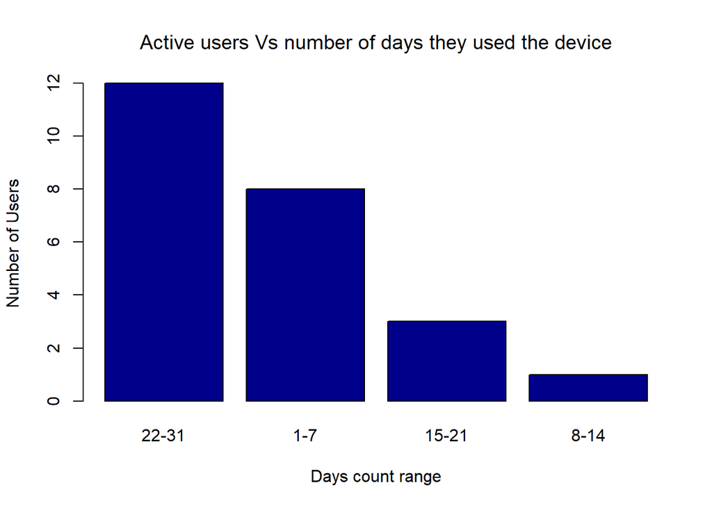

```r
barplot(users_percent$user_count, names.arg = users_percent$days_range,
        xlab = "Days count range", ylab = "Number of Users",
        col = "darkblue", main = "Active users Vs number of days they used the device",
        font.main = 1 )
```

creating pie plot to show the percentage of users and how many days they used the device

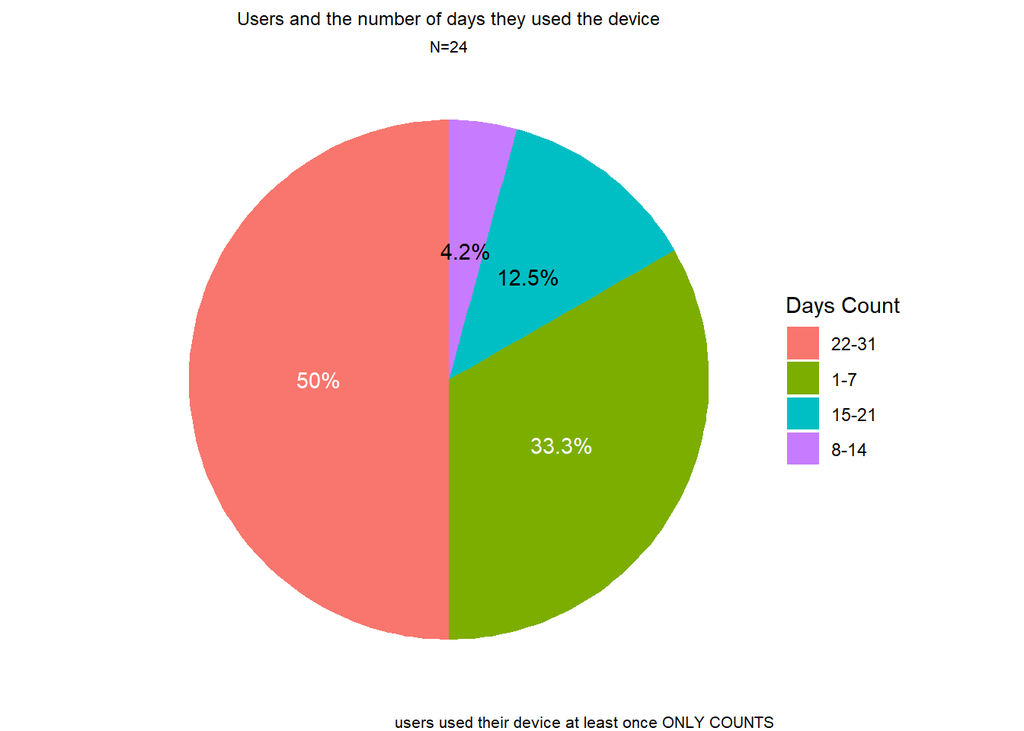

```r
#png(file="Piechart_users_days.png", width = 500, height = 500)
ggplot(users_percent, aes(x=1, y = user_percentage, fill= fct_inorder(days_range) )) +
  geom_col() +
  geom_text(aes(label= user_percentage_lbl),
            position= position_stack(vjust = .5),
            color = c("white","white",1,1)) +
  labs(title = "Users and the number of days they used the device",
       subtitle = "N=24",
       caption = "users used their device at least once ONLY COUNTS")+
  scale_fill_viridis_d()+
  scale_fill_discrete(name= "Days Count")+
  coord_polar(theta = "y")+
  theme_void() +
  theme( plot.title = element_text(hjust = .5, size = 9 ),
    plot.subtitle = element_text(hjust = 0.5, size = 8),
    plot.caption = element_text(hjust = 1, size = 8))
```

```r
#dev.off()
```

number of active users per day

```r
users_per_day <- activity_sleep_weight %>%
  group_by(activity_date) %>%
  summarise(users_count = n())

users_per_day
```

| activity_date | users_count |
| --- | --- |
| 2016-04-12 | 13 |
| 2016-04-13 | 14 |
| 2016-04-14 | 13 |
| 2016-04-15 | 17 |
| 2016-04-16 | 14 |
| 2016-04-17 | 12 |
| 2016-04-18 | 10 |
| 2016-04-19 | 14 |
| 2016-04-20 | 15 |
| 2016-04-21 | 15 |

[output cut: 21 more lines]

creating line chart to show how many users use the device per day

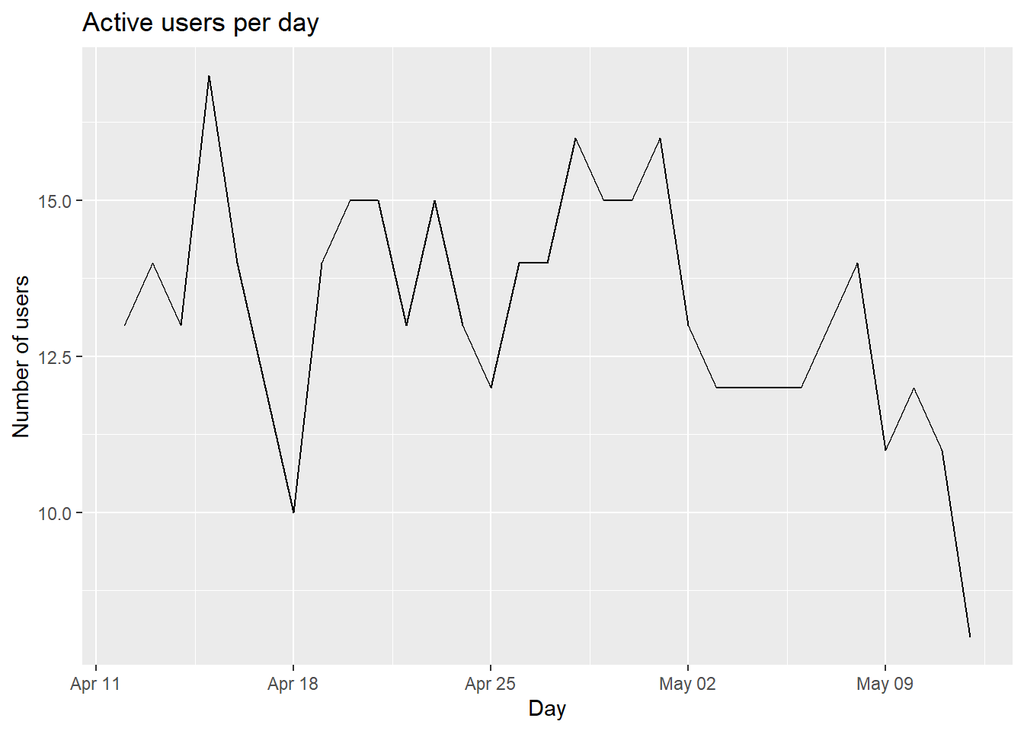

```r
#png("Active_users_perday.png", width = 800, height = 500)
ggplot(data = users_per_day, aes(x= activity_date, y = users_count)) +
  geom_line()+
  ggtitle("Active users per day")+
  xlab("Day")+
  ylab("Number of users")
```

```r
#dev.off()
```

Note: We need more data to confirm patterns

counting how many users log their weight

```r
users_log_weight <- activity_sleep_weight %>% filter(weight_kg >=1)

weight_logs <- users_log_weight %>%
  group_by(id) %>%
  summarise(weight_logs_count = n())

weight_logs
```

| id | weight_logs_count |
| --- | --- |
| 1503960366 | 2 |
| 1927972279 | 1 |
| 4558609924 | 1 |
| 5577150313 | 1 |
| 6962181067 | 30 |

creating a summary table for weight

```r
weight_logs_count <- nrow(weight_logs)
no_weight_logs_count <- nrow(table_sumarry)-nrow(weight_logs)
total_users <- nrow(table_sumarry)
weight_logs_perc <- round((weight_logs_count/total_users)*100,0)
no_weight_logs_perc <- round(no_weight_logs_count/total_users*100,0)
total_percent <- weight_logs_perc+ no_weight_logs_perc

users_summary_weight <- data.frame(users_behavior = c("weight logged","no weight logged","total"),
                            users_count = c(weight_logs_count,no_weight_logs_count,total_users),
                            users_perc = c(weight_logs_perc,no_weight_logs_perc,total_percent))

users_summary_weight
```

| users_behavior | users_count | users_perc |
| --- | --- | --- |
| weight logged | 5 | 21 |
| no weight logged | 19 | 79 |
| total | 24 | 100 |

the new table to be used in the pie chart

```r
users_summary_weight_no_tatal <- users_summary_weight %>% filter(users_perc < 100)
View(users_summary_weight_no_tatal)
users_summary_weight_no_tatal$users_perc_lbl <- str_c(users_summary_weight_no_tatal$users_perc,"%")

users_summary_weight_no_tatal
```

| users_behavior | users_count | users_perc | users_perc_lbl |
| --- | --- | --- | --- |
| weight logged | 5 | 21 | 21% |
| no weight logged | 19 | 79 | 79% |

creating a pie chart to show the percentage of users who logged and did not log their weitgh

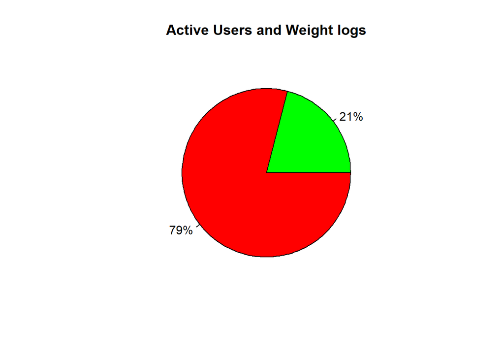

```r
#png("Active_Users_and_Weight_logs.png", width = 400, height = 400)
pie(users_summary_weight_no_tatal$users_perc,
    labels = users_summary_weight_no_tatal$users_perc_lbl,
    col = c("green","red"),
    main = "Active Users and Weight logs")
```

```r
#dev.off()
```